# cv12.R

Marek

2023-05-04

# Logisticka regresia

Objekty klasifikujeme do dvoch skupin, ma danu vlastnost Y=1, nema danu vlastnost Y=0. Modelujeme P(Y=1). Vezmime priklad z prednasky. Priklad Na klientovi banky sledujeme dva znaky, vzdelanie X=0, nema vs, X=1 ma vs a ci ma problem splatit uver, Y=1 - ma problem splatit, nema problem Y = 0. Model bude vyzerat

```r
library(latexpdf)
```

$$P(Y=1)=\frac{1}{1+e^{-b_0-b_1
x}}$$

```r
banka <- readxl::read_xlsx(path = '../data/banka.xlsx')
head(banka)
```

```
## # A tibble: 6 × 2
##   vzdelanie problem
##       <dbl>   <dbl>
## 1         0       1
## 2         0       1
## 3         0       1
## 4         0       1
## 5         0       1
## 6         0       1
```

kontingencna tabulka znakov

```r
table(banka$vzdelanie, banka$problem)
```

```
##
##       0   1
##   0 758 313
##   1 321  48
```

```r
logit <- glm(problem~., data=banka, family=binomial)
summary(logit)
```

```
##
## Call:
## glm(formula = problem ~ ., family = binomial, data = banka)
##
## Deviance Residuals:
##     Min       1Q   Median       3Q      Max
## -0.8315  -0.8315  -0.8315   1.5685   2.0197
##
## Coefficients:
##             Estimate Std. Error z value Pr(>|z|)
## (Intercept) -0.88448    0.06719 -13.164  < 2e-16 ***
## vzdelanie   -1.01576    0.16871  -6.021 1.74e-09 ***
## ---
## Signif. codes:  0 '***' 0.001 '**' 0.01 '*' 0.05 '.' 0.1 ' ' 1
##
## (Dispersion parameter for binomial family taken to be 1)
##
##     Null deviance: 1621.7  on 1439  degrees of freedom
## Residual deviance: 1579.4  on 1438  degrees of freedom
## AIC: 1583.4
##
## Number of Fisher Scoring iterations: 4
```

```r
summary(logit)$coef
```

```
##               Estimate Std. Error    z value     Pr(>|z|)
## (Intercept) -0.8844802 0.06718738 -13.164380 1.406886e-39
## vzdelanie   -1.0157599 0.16870879  -6.020788 1.735698e-09
```

Nakreslime data aj logisticku krivku, nie je velmi informacny graf

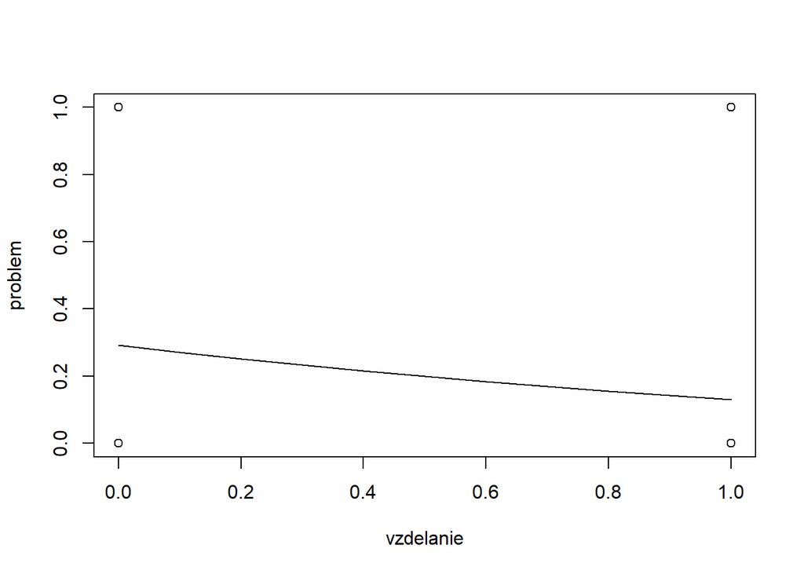

```r
b0 <- logit$coefficients[1]
b1 <- logit$coefficients[2]
xx <- seq(0, 1, 0.1)
yy <- 1/(1+exp(-b0-b1*xx))
plot(problem~vzdelanie, data = banka)
lines(xx, yy)
library(mlbench)
library(caret)
```

```r
library(ggplot2)
library(lattice)
library(corrplot)
library(Amelia)
data('PimaIndiansDiabetes2')
head(PimaIndiansDiabetes2)
```

```
##   pregnant glucose pressure triceps insulin mass pedigree age diabetes
## 1        6     148       72      35      NA 33.6    0.627  50      pos
## 2        1      85       66      29      NA 26.6    0.351  31      neg
## 3        8     183       64      NA      NA 23.3    0.672  32      pos
## 4        1      89       66      23      94 28.1    0.167  21      neg
## 5        0     137       40      35     168 43.1    2.288  33      pos
## 6        5     116       74      NA      NA 25.6    0.201  30      neg
```

Vyuzijeme vykove data, ktore pochadzaju z narodneho ustavu diabetu .. ma 8 vysvetlujucich premennych a jednu zavislu vsvetlovanu premennu cukrovka pos, neg, vyhodime vektory s chybajucimi datami

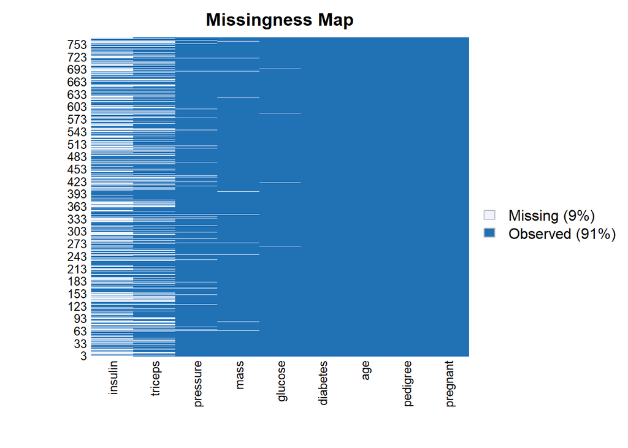

```r
missmap(PimaIndiansDiabetes2)
```

```r
diab <- na.omit(PimaIndiansDiabetes2)
nrow(diab)
```

```
## [1] 392
```

pozrieme na strukturu dat, najprv krabicove grafy pre nezavisle premenne

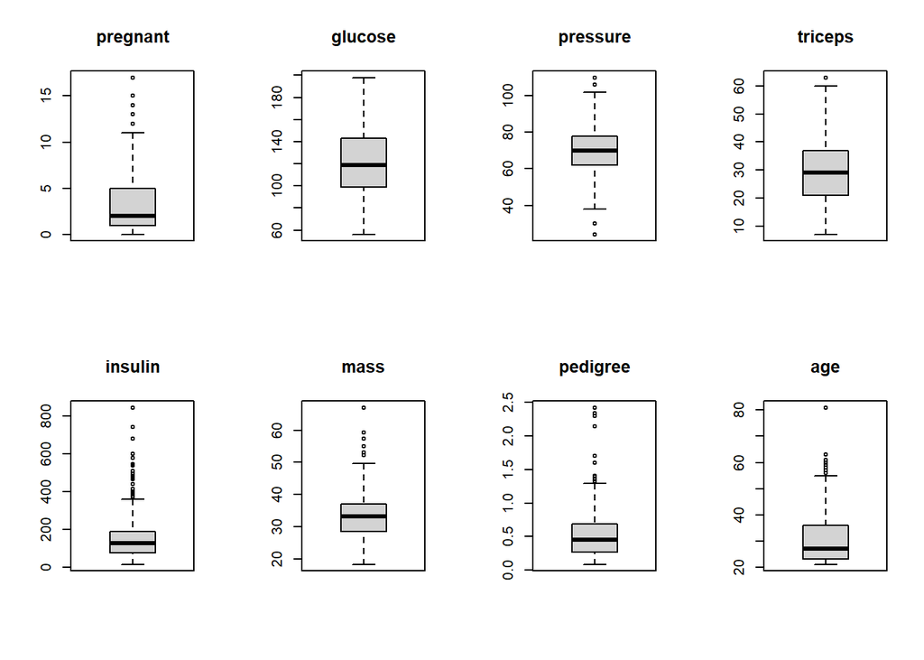

```r
par(mfrow=c(2,4))
for(i in 1:8){boxplot(diab[,i], main=names(diab)[i])}
```

lepsie su krabicove grafy rozdelene na cukrovku-ano, nie

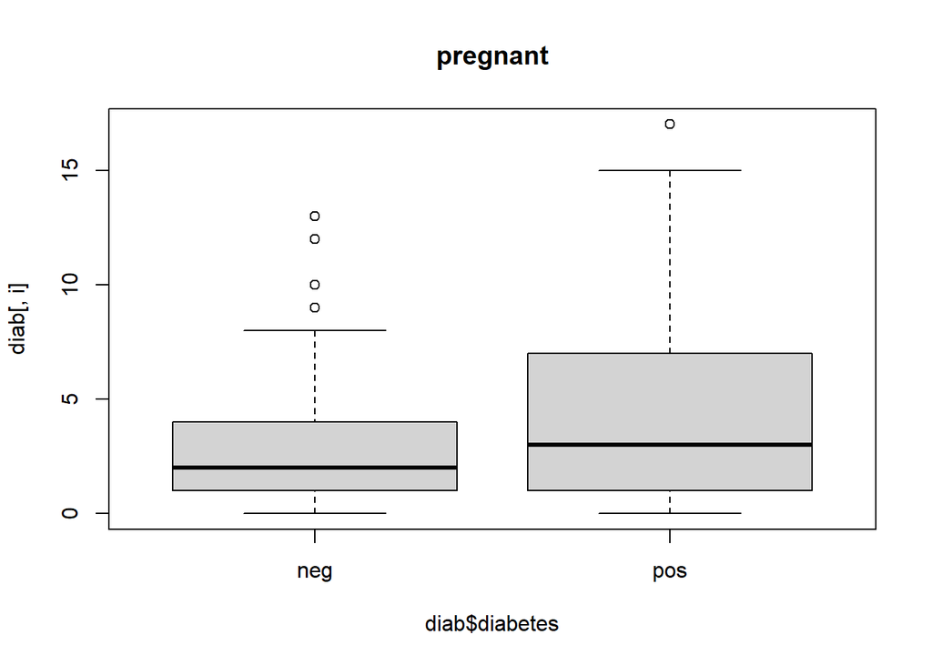

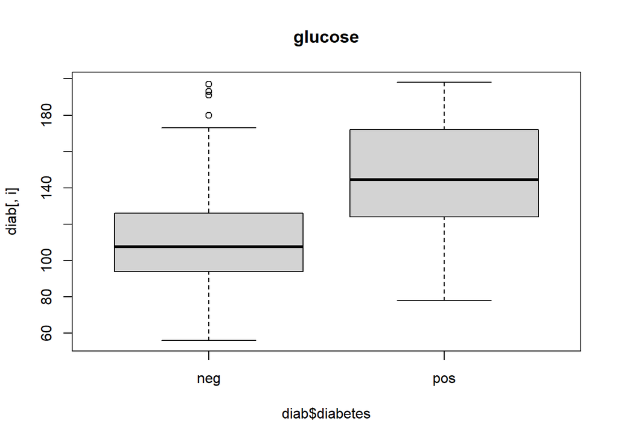

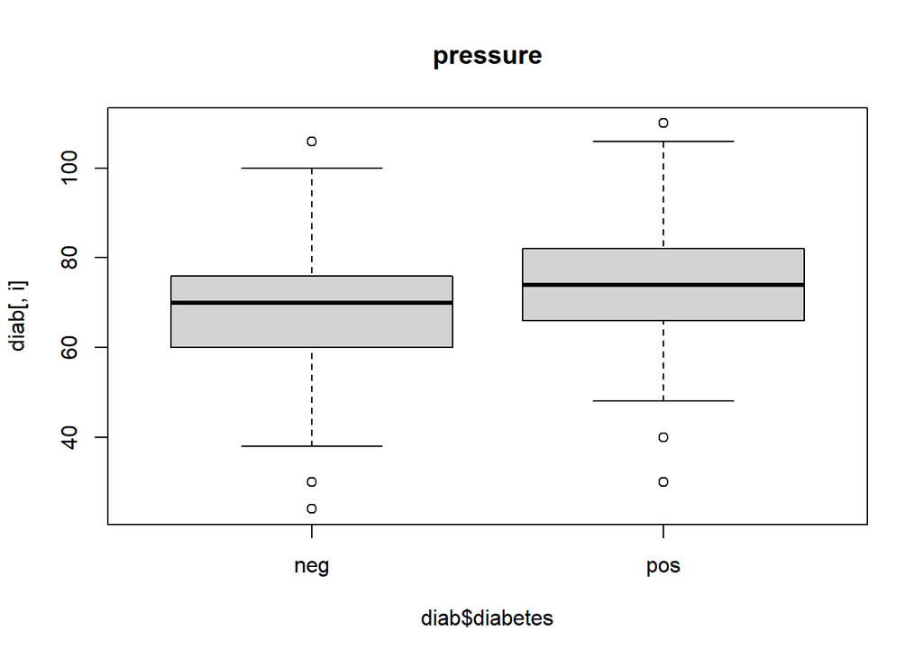

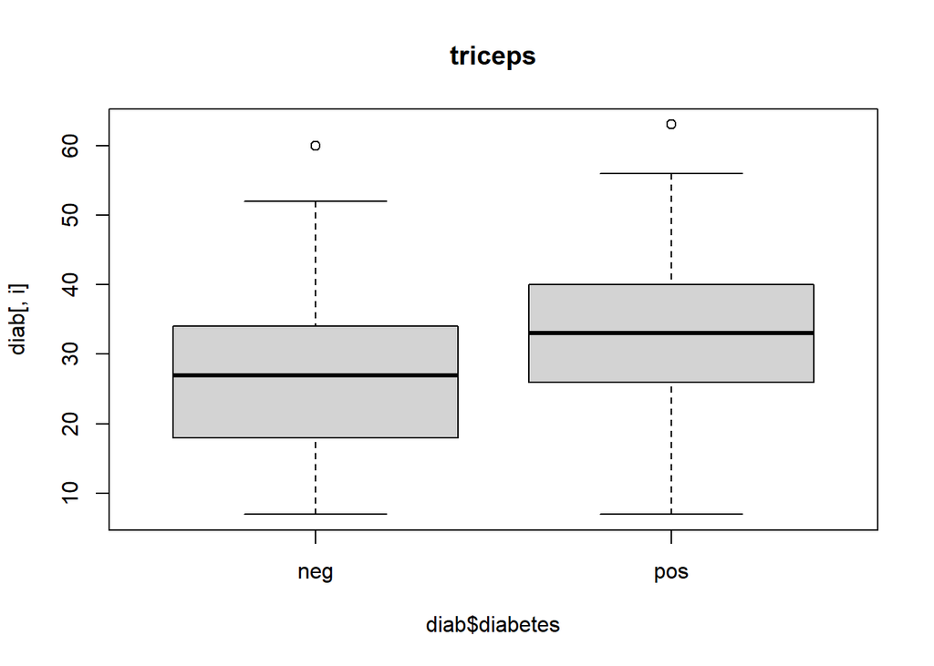

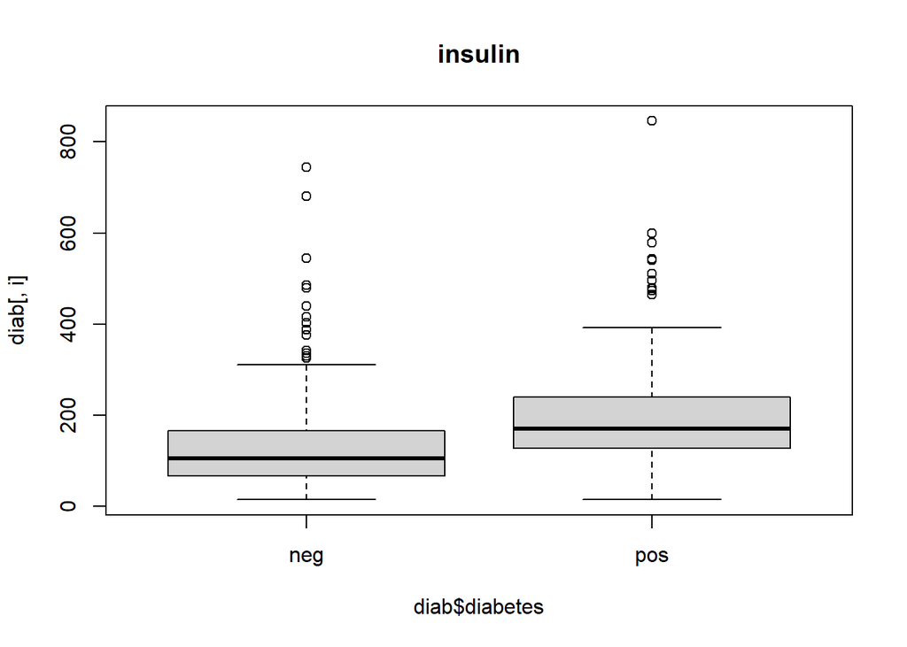

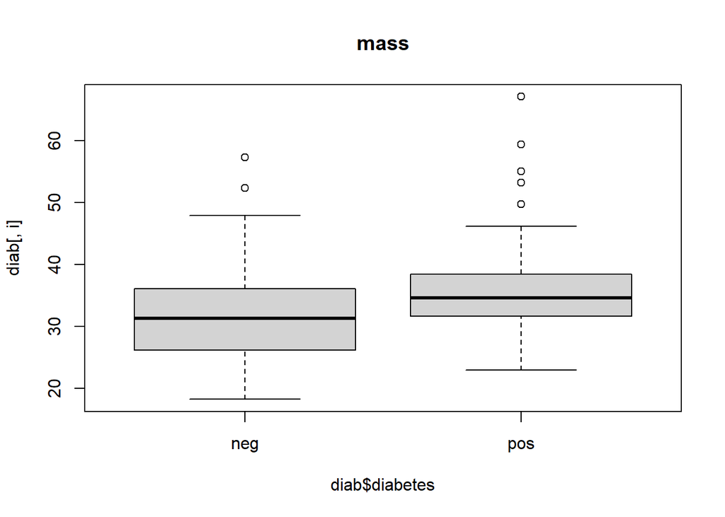

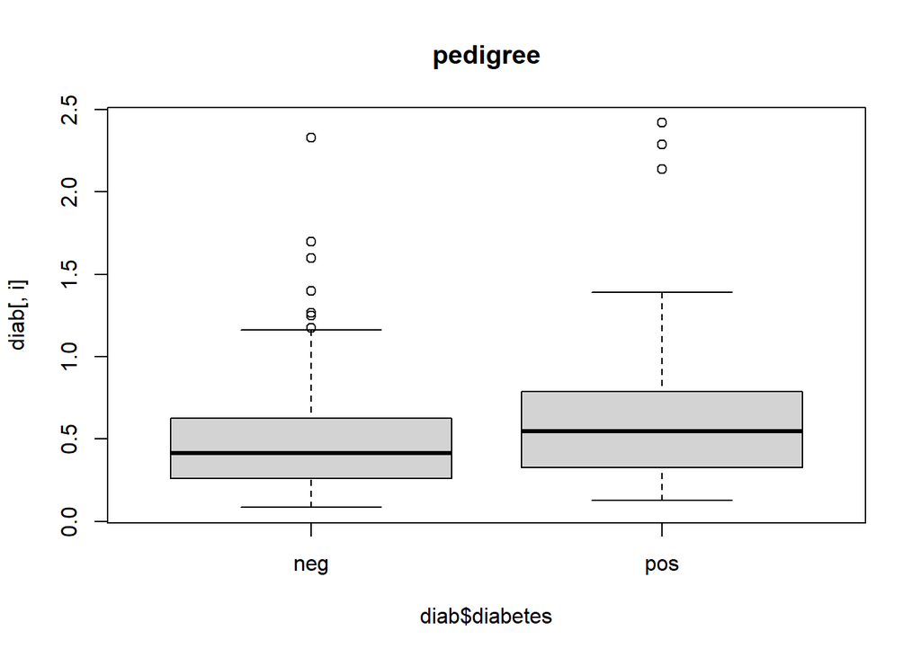

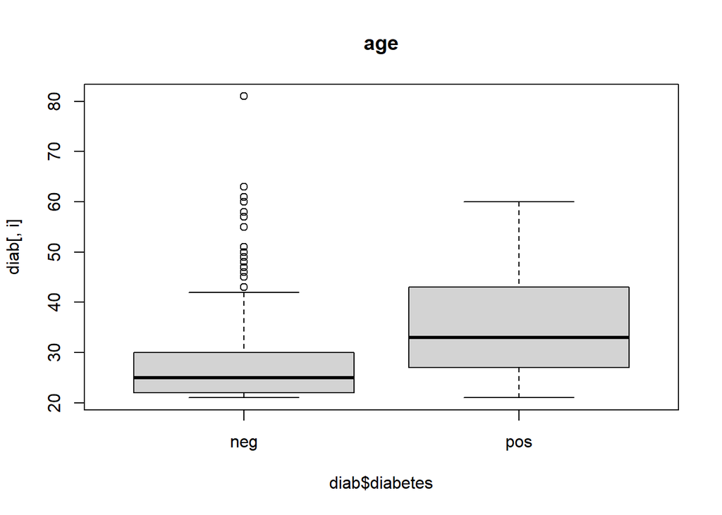

```r
invisible(lapply(1:8, function(i)
  boxplot(diab[,i]~diab$diabetes, main=names(diab)[i])))
```

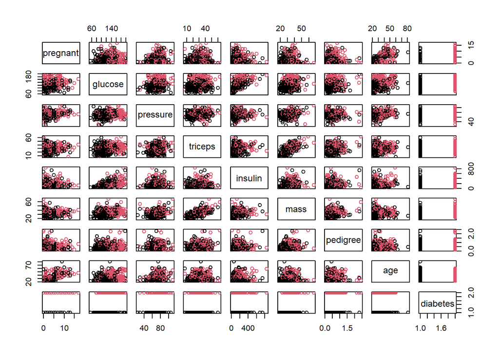

```r
par(mfrow=c(1,1))
pairs(diab, col=diab$diabetes)
```

najprv vezmime iba jednu premennu glucose, prelozme logisticku krivku

```r
logit1 <- glm(diabetes~glucose, data=diab, family=binomial)
logit1$coefficients
```

```
## (Intercept)     glucose
## -6.09552139  0.04242099
```

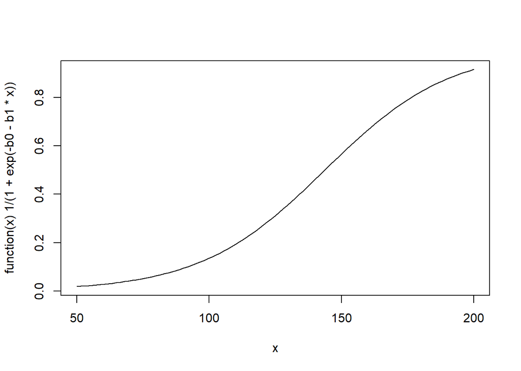

```r
b0 <- logit1$coefficients[1]
b1 <- logit1$coefficients[2]
plot(function(x) 1/(1+exp(-b0-b1*x)), xlim=c(50, 200))
```

```r
min(diab$glucose)
```

```
## [1] 56
```

```r
max(diab$glucose)
```

```
## [1] 198
```

este sme zabudli na korelacie medzi nezavislymi premennymi, moze problem, ze navzajom koreluju, kolinearita

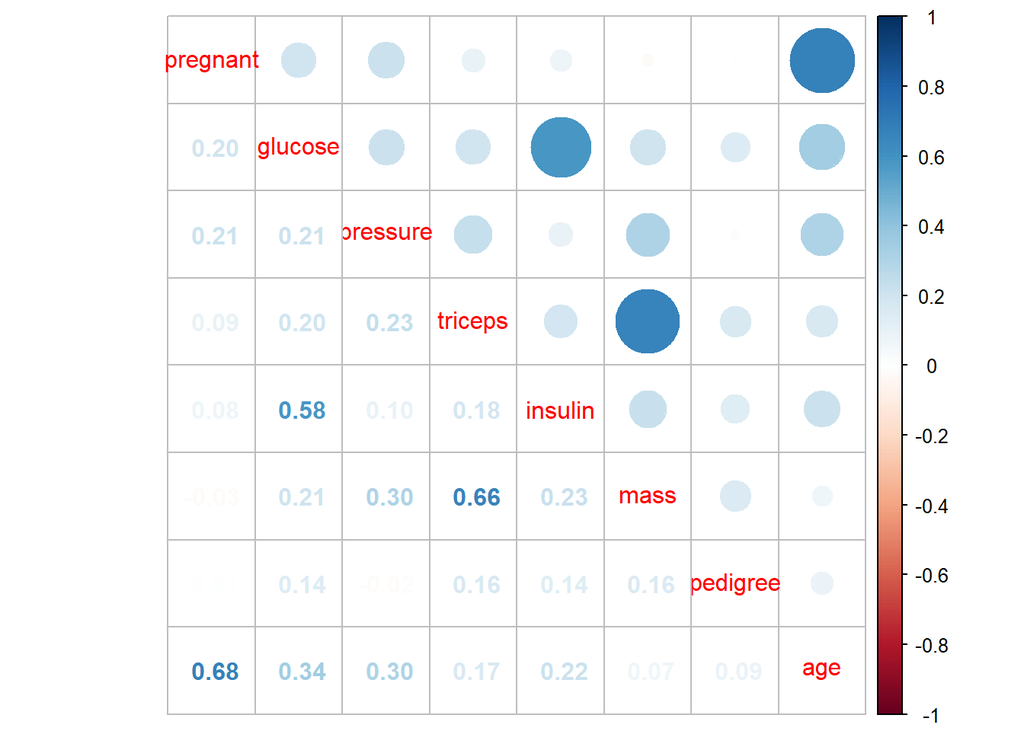

```r
kk <- cor(diab[,1:8])
corrplot.mixed(kk)
```

urobime logisticku regresiu so vsetkymi nezavislymi premennymi

```r
pimamodel <- glm(diabetes~., data = diab, family = binomial)
summary(pimamodel)
```

```
##
## Call:
## glm(formula = diabetes ~ ., family = binomial, data = diab)
##
## Deviance Residuals:
##     Min       1Q   Median       3Q      Max
## -2.7823  -0.6603  -0.3642   0.6409   2.5612
##
## Coefficients:
##               Estimate Std. Error z value Pr(>|z|)
## (Intercept) -1.004e+01  1.218e+00  -8.246  < 2e-16 ***
## pregnant     8.216e-02  5.543e-02   1.482  0.13825
## glucose      3.827e-02  5.768e-03   6.635 3.24e-11 ***
## pressure    -1.420e-03  1.183e-02  -0.120  0.90446
## triceps      1.122e-02  1.708e-02   0.657  0.51128
## insulin     -8.253e-04  1.306e-03  -0.632  0.52757
## mass         7.054e-02  2.734e-02   2.580  0.00989 **
## pedigree     1.141e+00  4.274e-01   2.669  0.00760 **
## age          3.395e-02  1.838e-02   1.847  0.06474 .
## ---
## Signif. codes:  0 '***' 0.001 '**' 0.01 '*' 0.05 '.' 0.1 ' ' 1
##
## (Dispersion parameter for binomial family taken to be 1)
##
##     Null deviance: 498.10  on 391  degrees of freedom
## Residual deviance: 344.02  on 383  degrees of freedom
## AIC: 362.02
##
## Number of Fisher Scoring iterations: 5
```

Niektore premenne nie je treba uvazovat v regresii, teraz to nebudeme riesit, ideme vyhodnotit kvalitu regresie. Hosmer-Lemeshow test (test dobrej zhody, ci ked rozdelime data do tried podla nejakeho pravidla su empiricke a napocitane pocetnosti v zhode). H0 su rovnake, model je ok

```r
library(glmtoolbox)
hltest(pimamodel)
```

```
##
##    The Hosmer-Lemeshow goodness-of-fit test
##
##  Group Size Observed  Expected
##      1   39        1  1.141980
##      2   39        2  2.261344
##      3   39        2  3.578250
##      4   39        3  5.270939
##      5   39       10  7.555515
##      6   39       11 10.706531
##      7   39       17 14.442709
##      8   39       21 20.494492
##      9   39       27 28.235741
##     10   39       35 34.338659
##     11    2        1  1.973841
##
##          Statistic =  40.72264
## degrees of freedom =  9
##            p-value =  5.6181e-06
```

p hodnota < 0.05, zamietame H0, z tohto hladiska model nie je vhodny likelihood Ratio test, porovnanie dvoch a viac modelov, ak uvedieme len jeden model, tak porovname s konstanym modelom. H0 je, ze medzi dvomi modelmi nie je rozdielu. Ak nie su rozdiely, vyberiem jednoduchsi, ak su rozdiely, tak zostava vp latnosti zlozitejsi.

```r
library(lmtest)
lrtest(pimamodel)
```

```
## Likelihood ratio test
##
## Model 1: diabetes ~ pregnant + glucose + pressure + triceps + insulin +
##     mass + pedigree + age
## Model 2: diabetes ~ 1
##   #Df  LogLik Df  Chisq Pr(>Chisq)
## 1   9 -172.01
## 2   1 -249.05 -8 154.08  < 2.2e-16 ***
## ---
## Signif. codes:  0 '***' 0.001 '**' 0.01 '*' 0.05 '.' 0.1 ' ' 1
```

Zamietame H0, vyberame model 1

```r
lrtest(pimamodel, logit1)
```

```
## Likelihood ratio test
##
## Model 1: diabetes ~ pregnant + glucose + pressure + triceps + insulin +
##     mass + pedigree + age
## Model 2: diabetes ~ glucose
##   #Df  LogLik Df  Chisq Pr(>Chisq)
## 1   9 -172.01
## 2   2 -193.33 -7 42.645  3.906e-07 ***
## ---
## Signif. codes:  0 '***' 0.001 '**' 0.01 '*' 0.05 '.' 0.1 ' ' 1
```

Aj tu zamietame H0, vyberame model 1 Kontingencne tabulky, aby sme zistili uspesnost predikcie cukrovky podla modelu pimamodel Najprv vypocitame pravdep. nastatia daneho javu

```r
probs <- predict(pimamodel, type = 'response')
```

nasa medzna hodnota nech je 0.5 (cut point), vsetko nad je pozitivny, vsetko pod je negativny

```r
pred <- ifelse(probs > 0.5, 'pos', 'neg')
pred
```

```
##     4     5     7     9    14    15    17    19    20    21    25    26    28
## "neg" "pos" "neg" "pos" "pos" "pos" "neg" "neg" "neg" "neg" "pos" "neg" "neg"
##    29    32    33    36    40    41    44    51    52    53    54    55    57
## "pos" "pos" "neg" "neg" "pos" "pos" "pos" "neg" "neg" "neg" "pos" "pos" "pos"
##    58    60    64    69    70    71    72    74    83    86    88    89    92
## "neg" "neg" "neg" "neg" "neg" "neg" "neg" "neg" "neg" "neg" "neg" "pos" "neg"
##    93    95    96    98    99   100   104   106   108   109   110   111   112
## "neg" "neg" "pos" "neg" "neg" "neg" "neg" "neg" "neg" "neg" "neg" "pos" "pos"
##   113   115   120   121   123   126   127   128   129   131   133   135   136
## "neg" "pos" "neg" "pos" "neg" "neg" "neg" "neg" "neg" "pos" "pos" "neg" "neg"
##   137   138   140   143   145   148   151   153   154   157   158   159   160
## "neg" "neg" "neg" "neg" "neg" "neg" "neg" "pos" "pos" "neg" "neg" "neg" "pos"
##   162   163   166   170   172   174   175   176   178   182   187   188   189
## "neg" "neg" "neg" "neg" "neg" "neg" "neg" "pos" "pos" "neg" "pos" "pos" "neg"
##   190   192   196   198   199   200   204   205   207   209   214   215   216
## "neg" "neg" "pos" "neg" "neg" "neg" "neg" "neg" "pos" "neg" "neg" "neg" "pos"
##   217   218   221   224   225   226   229   230   232   233   235   237   242
## "neg" "neg" "pos" "pos" "neg" "neg" "pos" "neg" "pos" "neg" "neg" "pos" "neg"
##   244   245   248   249   253   255   259   260   261   266   272   274   276
## "neg" "neg" "pos" "neg" "neg" "neg" "pos" "pos" "pos" "neg" "neg" "neg" "neg"
##   278   280   282   283   286   287   288   289   290   291   292   293   294
## "neg" "neg" "neg" "neg" "pos" "pos" "neg" "neg" "neg" "neg" "neg" "pos" "neg"
##   296   297   298   299   302   303   306   307   308   309   310   312   313
## "pos" "neg" "neg" "neg" "neg" "neg" "neg" "pos" "neg" "neg" "neg" "neg" "neg"
##   314   316   317   319   321   324   326   327   329   330   332   335   336
## "neg" "neg" "neg" "neg" "neg" "pos" "neg" "neg" "neg" "neg" "neg" "neg" "pos"
##   339   341   342   346   347   349   354   357   359   360   361   365   366
## "pos" "neg" "neg" "pos" "neg" "neg" "neg" "neg" "neg" "pos" "pos" "neg" "neg"
##   369   370   371   373   374   375   376   377   378   380   381   383   384
## "neg" "neg" "pos" "neg" "neg" "neg" "pos" "neg" "neg" "neg" "neg" "neg" "neg"
##   385   386   389   390   391   393   394   396   397   403   406   410   412
## "neg" "neg" "pos" "neg" "neg" "neg" "neg" "neg" "neg" "neg" "neg" "pos" "neg"
##   413   414   415   416   420   421   422   423   425   426   428   429   430
## "pos" "neg" "neg" "pos" "neg" "neg" "neg" "neg" "pos" "pos" "pos" "neg" "neg"
##   432   433   442   443   446   447   448   449   450   451   453   455   458
## "neg" "neg" "neg" "neg" "pos" "neg" "neg" "neg" "neg" "neg" "neg" "neg" "neg"
##   459   460   461   463   466   467   468   470   477   478   479   481   483
## "pos" "pos" "neg" "neg" "neg" "neg" "neg" "pos" "neg" "neg" "neg" "pos" "neg"
##   484   486   487   488   491   494   498   499   500   501   504   507   508
## "neg" "neg" "neg" "pos" "neg" "neg" "neg" "pos" "pos" "neg" "neg" "pos" "neg"
##   509   512   515   516   517   520   521   522   527   528   529   531   533
## "neg" "neg" "neg" "neg" "pos" "neg" "neg" "neg" "neg" "neg" "neg" "neg" "neg"
##   535   539   540   541   542   544   545   546   547   548   549   552   554
## "neg" "neg" "pos" "neg" "neg" "neg" "neg" "pos" "pos" "neg" "pos" "neg" "neg"
##   555   556   562   563   564   566   567   568   569   570   573   574   575
## "neg" "neg" "pos" "neg" "neg" "neg" "neg" "neg" "pos" "neg" "neg" "neg" "neg"
##   576   577   585   589   592   594   595   596   598   600   604   607   608
## "neg" "neg" "neg" "pos" "neg" "neg" "neg" "pos" "neg" "neg" "pos" "pos" "neg"
##   609   610   611   612   613   615   618   621   624   626   632   634   638
## "pos" "neg" "neg" "pos" "pos" "pos" "neg" "neg" "neg" "neg" "neg" "neg" "neg"
##   639   640   641   645   646   647   648   649   651   652   653   655   656
## "neg" "neg" "neg" "neg" "pos" "neg" "pos" "neg" "neg" "neg" "neg" "neg" "neg"
##   657   658   660   663   664   666   669   670   671   673   674   680   681
## "neg" "pos" "neg" "pos" "pos" "neg" "neg" "pos" "pos" "neg" "pos" "neg" "neg"
##   683   686   689   690   693   694   696   697   699   701   705   708   710
## "neg" "neg" "neg" "pos" "neg" "pos" "neg" "pos" "neg" "neg" "neg" "neg" "neg"
##   711   712   714   716   717   719   722   723   724   727   731   733   734
## "neg" "neg" "neg" "pos" "pos" "neg" "neg" "neg" "neg" "neg" "neg" "pos" "neg"
##   737   739   741   742   743   745   746   748   749   752   754   756   761
## "neg" "neg" "pos" "neg" "neg" "pos" "neg" "neg" "pos" "neg" "pos" "pos" "neg"
##   764   766
## "neg" "neg"
```

```r
table(diab$diabetes, pred)
```

```
##      pred
##       neg pos
##   neg 233  29
##   pos  56  74
```

```r
mean(pred==diab$diabetes)
```

```
## [1] 0.7831633
```

Uspesnost predpovede je 78% ROC krivka, hodnota AUC, kniznica ROCR, ROCit, pROC

```r
library(ROCR)
```

Napocitame pravdepodobnosti uz mame - probs, vytvorime objekt prediction

```r
pr <- prediction(probs, diab$diabetes)
pr
```

```
## A prediction instance
##   with 392 data points
```

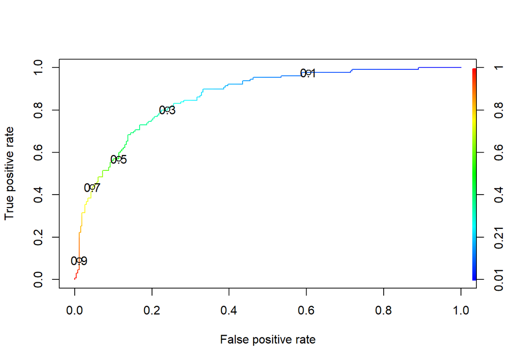

```r
prf <- performance(pr, 'tpr', 'fpr')
plot(prf, colorize=T)
plot(prf, colorize=T, print.cutoffs.at=seq(0.1, by=0.2))
```

Este zratame obsah plochy pod krivkou

```r
auc <- performance(pr, 'auc')
auc <- auc@y.values[[1]]
auc <- round(auc, 2)
#legend(0.6, 0.4, auc, title='AUC', cex=1)
```

teraz ideme riesit otazku, kolko premennych je vysvetlujucich, aby sme dostali co najoptimalnejsi model, pouzijeme proceduru step, MASS

```r
library(MASS)
model.step <- step(pimamodel)
```

```
## Start:  AIC=362.02
## diabetes ~ pregnant + glucose + pressure + triceps + insulin +
##     mass + pedigree + age
##
##            Df Deviance    AIC
## - pressure  1   344.04 360.04
## - insulin   1   344.42 360.42
## - triceps   1   344.45 360.45
## <none>          344.02 362.02
## - pregnant  1   346.24 362.24
## - age       1   347.55 363.55
## - mass      1   350.89 366.89
## - pedigree  1   351.58 367.58
## - glucose   1   396.95 412.95
##
## Step:  AIC=360.04
## diabetes ~ pregnant + glucose + triceps + insulin + mass + pedigree +
##     age
##
##            Df Deviance    AIC
## - insulin   1   344.42 358.42
## - triceps   1   344.46 358.46
## <none>          344.04 360.04
## - pregnant  1   346.24 360.24
## - age       1   347.60 361.60
## - mass      1   351.28 365.28
## - pedigree  1   351.67 365.67
## - glucose   1   397.31 411.31
##
## Step:  AIC=358.42
## diabetes ~ pregnant + glucose + triceps + mass + pedigree + age
##
##            Df Deviance    AIC
## - triceps   1   344.89 356.89
## <none>          344.42 358.42
## - pregnant  1   346.74 358.74
## - age       1   347.87 359.87
## - mass      1   351.32 363.32
## - pedigree  1   351.90 363.90
## - glucose   1   411.11 423.11
##
## Step:  AIC=356.89
## diabetes ~ pregnant + glucose + mass + pedigree + age
##
##            Df Deviance    AIC
## <none>          344.89 356.89
## - pregnant  1   347.23 357.23
## - age       1   348.72 358.72
## - pedigree  1   352.72 362.72
## - mass      1   360.44 370.44
## - glucose   1   411.85 421.85
```

```r
model.step1 <- stepAIC(pimamodel)
```

```
## Start:  AIC=362.02
## diabetes ~ pregnant + glucose + pressure + triceps + insulin +
##     mass + pedigree + age
##
##            Df Deviance    AIC
## - pressure  1   344.04 360.04
## - insulin   1   344.42 360.42
## - triceps   1   344.45 360.45
## <none>          344.02 362.02
## - pregnant  1   346.24 362.24
## - age       1   347.55 363.55
## - mass      1   350.89 366.89
## - pedigree  1   351.58 367.58
## - glucose   1   396.95 412.95
##
## Step:  AIC=360.04
## diabetes ~ pregnant + glucose + triceps + insulin + mass + pedigree +
##     age
##
##            Df Deviance    AIC
## - insulin   1   344.42 358.42
## - triceps   1   344.46 358.46
## <none>          344.04 360.04
## - pregnant  1   346.24 360.24
## - age       1   347.60 361.60
## - mass      1   351.28 365.28
## - pedigree  1   351.67 365.67
## - glucose   1   397.31 411.31
##
## Step:  AIC=358.42
## diabetes ~ pregnant + glucose + triceps + mass + pedigree + age
##
##            Df Deviance    AIC
## - triceps   1   344.89 356.89
## <none>          344.42 358.42
## - pregnant  1   346.74 358.74
## - age       1   347.87 359.87
## - mass      1   351.32 363.32
## - pedigree  1   351.90 363.90
## - glucose   1   411.11 423.11
##
## Step:  AIC=356.89
## diabetes ~ pregnant + glucose + mass + pedigree + age
##
##            Df Deviance    AIC
## <none>          344.89 356.89
## - pregnant  1   347.23 357.23
## - age       1   348.72 358.72
## - pedigree  1   352.72 362.72
## - mass      1   360.44 370.44
## - glucose   1   411.85 421.85
```

Likelihood Ratio test na porovnanie modelov

```r
lrtest(pimamodel, model.step)
```

```
## Likelihood ratio test
##
## Model 1: diabetes ~ pregnant + glucose + pressure + triceps + insulin +
##     mass + pedigree + age
## Model 2: diabetes ~ pregnant + glucose + mass + pedigree + age
##   #Df  LogLik Df  Chisq Pr(>Chisq)
## 1   9 -172.01
## 2   6 -172.44 -3 0.8639     0.8341
```

p hodnota >0.05, modely su porovnatelne, vyberame jednoduchsi % uspesnosti, ROC, AUC

```r
probs <- predict(model.step, type = 'response')
pred <- ifelse(probs > 0.5, 'pos', 'neg')
table(diab$diabetes, pred)
```

```
##      pred
##       neg pos
##   neg 232  30
##   pos  55  75
```

```r
mean(pred==diab$diabetes)
```

```
## [1] 0.7831633
```

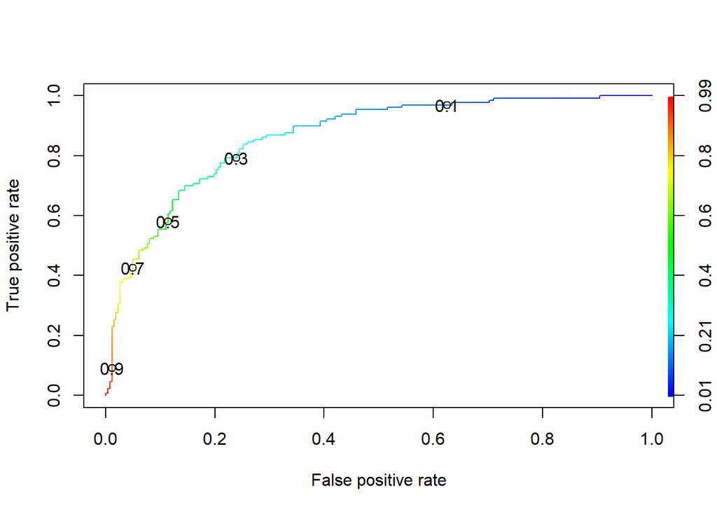

```r
pr <- prediction(probs, diab$diabetes)
prf <- performance(pr, 'tpr', 'fpr')
plot(prf, colorize=T)
plot(prf, colorize=T, print.cutoffs.at=seq(0.1, by=0.2))
```

Este zratame obsah plochy pod krivkou

```r
auc <- performance(pr, 'auc')
auc <- auc@y.values[[1]]
auc <- round(auc, 2)
#legend(0.6, 0.4, auc, title='AUC', cex=1)
```